# RIOS Research - Inclusive Teaching Text Analysis - Part 1

Sokona Mangane

2023-06-02

# Introduction

My name is Sokona Mangane and I’m from Brooklyn, NY. I’m a Bates College Alumna and majored in Mathematics, and minored in Digital and Computational Studies. Below is the research I’ve conducted while I was finishing my time at Bates. In the *Data Cleaning* folder, I created dataframes which identifies each word in the inclusive teaching section and if they should be considered JEDI (related to justice, equity, diversity, and inclusion). Below, I import the data from that folder to analyze the word frequency of DEI related words and how they change over time. I create tables, box plots, bar plots, and line graphs. My colleague, Yuhao helped to comment out my code and calculate statistics about the DEI % of each article. He also conducted a network analysis, which is another folder titled *Network Analysis*.

# Setup

I import the necessary packages (same code in the Data Cleaning markdown in the *Data Cleaning* folder).

```r
# store string containing all required packages
my_packages <- c('varhandle', 'skimr', 'tidyverse', 'tidytext', 'stopwords', "wordcloud", "reshape2", "ggraph", "kableExtra",'readr', 'dplyr', "igraph","SnowballC", "knitr", "ggrepel", "ggtext", "showtext", "rcartocolor", "gridExtra", "cowplot")

# store all installed packages
ya_installed <- library()$results[,1]

# check whether required packages are already installed and grab only those that still need installation
need_install<-my_packages[!(my_packages %in% ya_installed)]

# install required packages
lapply(need_install, install.packages, character.only = TRUE)

#similar process as above, but loading the packages

# store all installed packages
ya_loaded <- (.packages())

# check whether required packages are already installed and grab only those that still need installation
need_load<-my_packages[!(my_packages %in% ya_loaded)]

# load required packages
lapply(need_load, require, character.only = TRUE)
```

Below I specify global options that I want for all of my code chunks.

```r
knitr::opts_chunk$set(warning = FALSE, # doesn't print warnings
                      message = FALSE) # doesn't print messages
```

I import the required datasets for analysis, which were exported from the Data Cleaning folder.

```r
# import the datasets which were exported from the Data Cleaning folder

#original cleaned dataset
rios_data <- read_csv("https://raw.githubusercontent.com/smsokona/RIOS---CourseSource-Research/master/Data%20Cleaning/Data%20for%20Export/rios_data.csv")

# cleaned tokenized dataset
rios_data_tokenized <- read_csv("https://raw.githubusercontent.com/smsokona/RIOS---CourseSource-Research/master/Data%20Cleaning/Data%20for%20Export/rios_data_tokenized.csv")

# cleaned tokenized dataset for two word phrases
rios_data_tokenized2 <- read_csv("https://raw.githubusercontent.com/smsokona/RIOS---CourseSource-Research/master/Data%20Cleaning/Data%20for%20Export/rios_data_tokenized2.csv")

# cleaned tokenized dataset for three word phrases
rios_data_tokenized3 <- read_csv("https://raw.githubusercontent.com/smsokona/RIOS---CourseSource-Research/master/Data%20Cleaning/Data%20for%20Export/rios_data_tokenized3.csv")

#cleaned dataset of words counts, grouped by year
dei_word_counts <- read_csv("https://raw.githubusercontent.com/smsokona/RIOS---CourseSource-Research/master/Data%20Cleaning/Data%20for%20Export/dei_word_counts.csv")
```

# Paper-wise statistics

Yuhao creates a column of the percentage of DEI words for each article.

```r
# store a vector of 256 zero's (the length of our data frame, to be replaced below)
DEI_count<-rep(0, nrow(rios_data))

# count the amount of DEI words in each article and store the count in the vector above
for(i in 1:length(DEI_count)){
  for (k in 1:length(rios_data_tokenized$Title)){
    if( rios_data_tokenized$dei_relatedit[k] == "TRUE" && rios_data_tokenized$article_num[k] == rios_data$article_num[i] ){
      DEI_count[i]=DEI_count[i]+1
    }
  }
}

# store the DEI count in the df
rios_data$`DEI Word count` <- DEI_count

# calculate and store the % of DEI words in the df
rios_data$`DEI_Words_%` <-(rios_data$`DEI Word count`/rios_data$`Word Count of Inclusive Teaching?`)*100
```

# Exploratory Data Analysis: Word Count

## Word Count of Inclusive Teaching Text Over Time & Average Word Count Before and After 2018

The boxplot below visualizes the word count of the Inclusive Teaching Section over time. The Word count increases in the 2019-2022 group compared to the years prior, and we also start to see more outliers. To more clearly see the shift before and after 2018, I also create a bar plot of the average word count, comparing the word count before and after 2018. I also conduct a one-sample t-test. Overall, since the creation of Course Source, the word count of the Inclusive Teaching Section has increased.

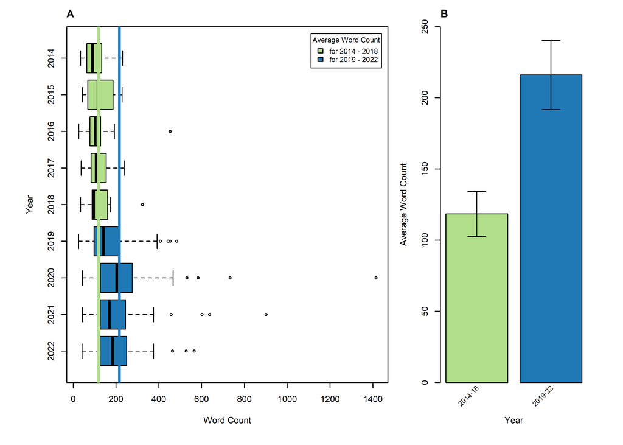

```r
## Code for box plot

wrdctboxplot <- function(){
  # factor years to reorder from oldest to most recent (to be consistent with table below)
  rios_data$Year <- factor(rios_data$Year , levels=c("2022", "2021", "2020", "2019", "2018", "2017", "2016", "2015", "2014"))

  # create box plot and store in function
  boxplot(`Word Count of Inclusive Teaching?`~ Year,
          data=rios_data,
          ylab="Year",
          xlab="Word Count",
          horizontal = TRUE,
          # color groups (color blind safe colors) based on the shift (2014-2018 and 2019-2022)
          col = c("#1f78b4", "#1f78b4", "#1f78b4", "#1f78b4", "#b2df8a","#b2df8a", "#b2df8a", "#b2df8a", "#b2df8a"))

  # label box plot and make title left-aligned
  title("A", adj = 0)

  # color and impose horizontal line of 2014 - 2018 group average word count
  abline(v = 118.4868, col = "#b2df8a", lty = "solid", lwd = 3)

  # color and impose horizontal line of 2019 - 2022 group average word count
  abline(v = 216.0667, col = "#1f78b4",lty = "solid", lwd = 3)

  # impose legend which explain horizontal lines
  legend("topright", inset=.02, title="Average Word Count", c("for 2014 - 2018","for 2019 - 2022"), fill=c("#b2df8a", "#1f78b4"), horiz=FALSE, cex=0.8)

  # unfactor years
  rios_data$Year <-  unfactor(rios_data$Year)
}

## code for bar plot

# store data for bar plot
data <- rios_data %>%
  group_by(`Group Year`) %>%
  # calculate avg. wrd ct, length, and standard deviation for each group year
  summarise(Avg_Wrd_Ct = mean(`Word Count of Inclusive Teaching?`, na.rm = TRUE),
            n = n(),
            sd = sd(`Word Count of Inclusive Teaching?`, na.rm = TRUE)) %>%
  # calculate the standard error and  the standard error multiplied by the value of the t-distribution for 0.5
  mutate(se = sd/sqrt(n),
         ic = se * qt((1-0.05)/2 + 0.5, n-1))


# A function to add arrows on the chart
error.bar <- function(x, y, upper, lower=upper, length=0.1,...){
  arrows(x,y+upper, x, y-lower, angle=90, code=3, length=length, ...)
}

# creates side by side plot of box plot and bar plot (1 row, 2 columns), specify size of labels and margins (bottom, left, top, right)
par(mfrow = c(1,2), cex = 0.6, mai = c(0.7,0.75,0.3,0.4))

# define area for boxplot
par(fig = c(0,0.68,0,1), new = TRUE)

# run box plot
wrdctboxplot()

# define area for bar plot
par(fig=c(0.6,1,0,1), new = TRUE)

# store the base barplot in a variable
base_barplot <- barplot(data$Avg_Wrd_Ct ~ data$`Group Year`, axis.lty = 1, ylim = c(0,250), col = c("#b2df8a", "#1f78b4"), xlab = "Year", ylab = "Average Word Count", xaxt = "n")

# add the error bar on the plot using my "error bar" function and run
error.bar(base_barplot, data$Avg_Wrd_Ct, data$ic)

# rotate the x axis on the barplot
text(base_barplot, par("usr")[3], srt = 45, labels = c("2014-18", "2019-22") , adj = c(1.1,1.1), xpd = TRUE, cex=.79)

# label bar plot and make title left-aligned
title("B", adj = 0)
```

```r
# conduct a one sample t-test
testbygroupyr <- t.test(formula = `Word Count of Inclusive Teaching?` ~ `Group Year`, data = rios_data)

# print
testbygroupyr #p-value = 1.557e-10, confidence interval:  -126.37537  -68.78427, df = 254?!
```

```
##
##  Welch Two Sample t-test
##
## data:  Word Count of Inclusive Teaching? by Group Year
## t = -6.6736, df = 254, p-value = 1.557e-10
## alternative hypothesis: true difference in means between group 2014 - 2018 and group 2019 - 2022 is not equal to 0
## 95 percent confidence interval:
##  -126.37537  -68.78427
## sample estimates:
## mean in group 2014 - 2018 mean in group 2019 - 2022
##                  118.4868                  216.0667
```

Presented below is an in-depth look at what’s visualized above.

```r
# create skim() table
rios_data %>%
  # group by year
  group_by(Year) %>%
  # present an overview only on the 'word count' column
  skim(starts_with("Word Count")) %>%
  # remove the variable and completion rate column
  select(3,4,6:13)  %>%
  # round the mean and sd columns; calculate the variance
  mutate(numeric.mean = round(numeric.mean, digits = 2), numeric.sd = round(numeric.sd, digits = 2), variance = (numeric.sd)^2) %>%
  # rename all columns
  rename("Mean" = "numeric.mean",
         "Missing?" = "n_missing",
         "SD" = "numeric.sd",
         "Variance" = "variance",
         "Min" = "numeric.p0",
         "25 Q" = "numeric.p25",
         "Median" = "numeric.p50",
         "75 Q" = "numeric.p75",
         "Max" = "numeric.p100",
         "Histogram" = "numeric.hist") %>%
  # turn this table into a nicely formatted table
  kable() %>%
  kable_minimal()
```

| Year | Missing? | Mean | SD | Min | 25 Q | Median | 75 Q | Max | Histogram | Variance |
| --- | --- | --- | --- | --- | --- | --- | --- | --- | --- | --- |
| 2014 | 0 | 106.85 | 58.05 | 34 | 63.00 | 90.0 | 133.00 | 230 | ▇▇▆▁▃ | 3369.802 |
| 2015 | 0 | 122.57 | 61.70 | 43 | 70.50 | 116.0 | 174.25 | 228 | ▇▅▃▂▅ | 3806.890 |
| 2016 | 0 | 115.80 | 89.83 | 26 | 79.00 | 103.0 | 127.50 | 453 | ▇▅▁▁▁ | 8069.429 |
| 2017 | 0 | 123.00 | 56.55 | 37 | 83.50 | 107.0 | 154.00 | 238 | ▃▇▃▃▂ | 3197.903 |
| 2018 | 0 | 124.70 | 80.22 | 34 | 89.75 | 95.0 | 144.75 | 324 | ▆▇▃▁▂ | 6435.248 |
| 2019 | 0 | 173.33 | 114.77 | 25 | 98.75 | 141.5 | 213.75 | 483 | ▆▇▃▁▂ | 13172.153 |
| 2020 | 0 | 249.45 | 218.46 | 43 | 126.50 | 203.0 | 276.00 | 1415 | ▇▂▁▁▁ | 47724.772 |
| 2021 | 0 | 224.62 | 170.73 | 43 | 125.75 | 169.0 | 241.75 | 901 | ▇▃▁▁▁ | 29148.733 |
| 2022 | 0 | 210.74 | 118.28 | 41 | 124.00 | 183.0 | 249.50 | 565 | ▅▇▂▁▁ | 13990.158 |

## Average Word Count For Workshop Attendees

Here I create a plot of the average word count comparing the word count for articles which include authors that attended CourseSource workshops and those that didn’t. I also conduct a one-sample t-test. Overall, the word count for those who’ve attended workshops are higher.

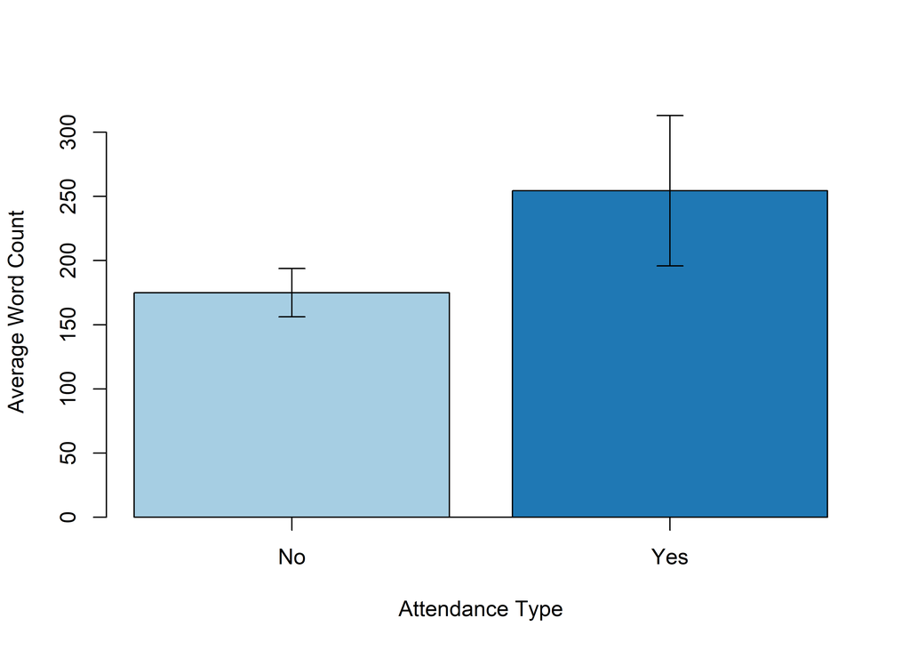

```r
# store data for bar plot
data1 <- rios_data %>%
  group_by(`Attended Workshop?`) %>%
  # calculate avg. wrd ct, length, and standard deviation for each group
  summarise(Avg_Wrd_Ct = mean(`Word Count of Inclusive Teaching?`, na.rm = TRUE),
            n = n(),
            sd = sd(`Word Count of Inclusive Teaching?`, na.rm = TRUE)) %>%
  # calculate the standard error and the standard error multiplied by the value of the t-distribution for 0.5
  mutate(se = sd/sqrt(n),
         ic = se * qt((1-0.05)/2 + 0.5, n-1))

# store the base barplot in a variable
base_barplot1 <- barplot(data1$Avg_Wrd_Ct ~ data1$`Attended Workshop?`, axis.lty = 1, ylim = c(0,320), col = c("#a6cee3", "#1f78b4"), xlab = "Attendance Type", ylab = "Average Word Count", names.arg = data1$`Attended Workshop?`)

# add the error bar on the plot using my "error bar" function and run
error.bar(base_barplot1, data1$Avg_Wrd_Ct, data1$ic)
```

```r
# conduct a one sample t-test
testbyattendance <- t.test(formula = `Word Count of Inclusive Teaching?` ~ `Attended Workshop?`, data = rios_data)

# print
testbyattendance #p-value = 0.01227, confidence interval (difference btw. means):  -140.73083  -18.08968, df = 46.607
```

```
##
##  Welch Two Sample t-test
##
## data:  Word Count of Inclusive Teaching? by Attended Workshop?
## t = -2.6058, df = 46.607, p-value = 0.01227
## alternative hypothesis: true difference in means between group No and group Yes is not equal to 0
## 95 percent confidence interval:
##  -140.73083  -18.08968
## sample estimates:
##  mean in group No mean in group Yes
##          175.0000          254.4103
```

### Average *JEDI* Word Count for Workshop Attendees

Below, I create a plot of the average *JEDI* word count, comparing the word count for articles which include authors that attended CourseSource workshops and those that didn’t. I also conduct a one-sample t-test. Although the average JEDI word count is much lower here, we can see that those who’ve attended workshops have a relatively higher average word count, like we see above.

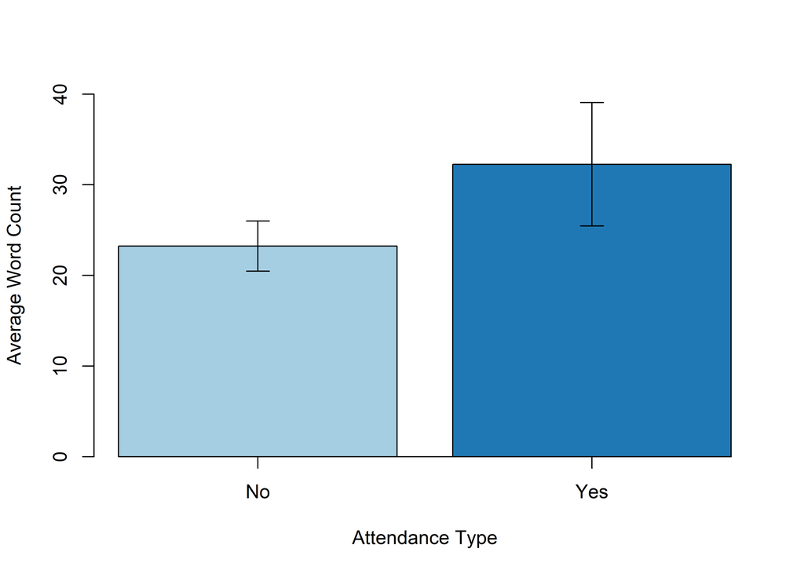

```r
# store data for bar plot
dei_by_workshop_data <- rios_data %>%
  group_by(`Attended Workshop?`) %>%
  # calculate avg. wrd ct, length, and standard deviation for each group
  summarise(Avg_word_count = mean(`DEI Word count`, na.rm = TRUE),
            n = n(),
            sd = sd(`DEI Word count`, na.rm = TRUE)) %>%
  # calculate the standard error and  the standard error multiplied by the value of the t-distribution for 0.5
  mutate(se = sd/sqrt(n),
         ic = se * qt((1-0.05)/2 + 0.5, n-1))

# store the base barplot in a variable
base_barplot2 <- barplot(dei_by_workshop_data$Avg_word_count ~ dei_by_workshop_data$`Attended Workshop?`, axis.lty = 1, ylim = c(0,40), col = c("#a6cee3", "#1f78b4"), xlab = "Attendance Type", ylab = "Average Word Count", names.arg = dei_by_workshop_data$`Attended Workshop?`)

# add the error bar on the plot using my "error bar" function and run
error.bar(base_barplot2, dei_by_workshop_data$Avg_word_count, dei_by_workshop_data$ic)
```

```r
# conduct a one sample t-test
jeditestbyattendance <- t.test(formula = `DEI Word count` ~ `Attended Workshop?`, data = rios_data)

# print
jeditestbyattendance #p-value = 0.02788, confidence interval (difference btw. means):  -8.1950137 -0.4900862, df = 54.354
```

```
##
##  Welch Two Sample t-test
##
## data:  DEI Word count by Attended Workshop?
## t = -2.4814, df = 52.139, p-value = 0.01635
## alternative hypothesis: true difference in means between group No and group Yes is not equal to 0
## 95 percent confidence interval:
##  -16.324659  -1.727332
## sample estimates:
##  mean in group No mean in group Yes
##          23.23041          32.25641
```

# Exploratory Data Analysis: Word Frequency

## What are the most common “DEI” Words in the Inclusive Teaching Description?

About 17% of words in the Inclusive Teaching Text are DEI related (761/4,469). Looking at the most common DEI words gives us an idea of what DEI words are being used the most, and what does that tell us about how the authors are being inclusive. According to the table below, the words “inclusive”, “students”, and “diversity” are the most commons DEI words.

However, it’s no surprise that students is the most common, as authors will inevitably have to mention how their article is inclusive of *students*. Additionally, the title of this section for which these descriptions are under is called “Inclusive Teaching”, so one could have a lengthy description under this section, without including any of the words from `dei_keywords` and then mention “inclusive teaching” to be included in this category.

```r
# print out top 15 most common DEI related words, USE KABLE()
rios_data_tokenized %>%
  filter(dei_relatedit == "TRUE") %>%
  count(inclusive_teach_tokens, sort = TRUE) %>%
  # print the top 15
  head(15) %>%
  # rename columns
  rename("Word" = "inclusive_teach_tokens",
         "Count" = "n") %>%
  # turn this table into a nicely formatted table
  kable() %>%
  kable_minimal()
```

| Word | Count |
| --- | --- |
| students | 1389 |
| inclusive | 123 |
| diversity | 115 |
| diverse | 100 |
| opportunity | 94 |
| individual | 72 |
| engage | 66 |
| environment | 64 |
| backgrounds | 57 |
| participate | 57 |
| community | 55 |
| visual | 53 |
| access | 52 |
| participation | 52 |
| active | 50 |

## Word Cloud

Word clouds are another way of visualizing which words are being used the most. I removed the word “students”, since it’s an outlier. There are still so many DEI related words, so I create a word cloud of the *stemmed* DEI related words.

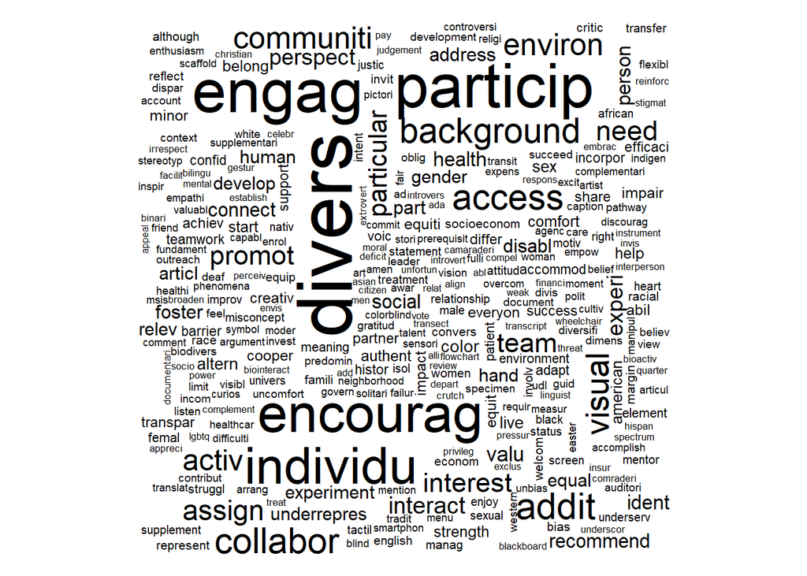

```r
# create word cloud of stemmed DEI related words
rios_data_tokenized %>%
  filter(inclusive_teach_tokens != "students" & dei_relatedit == "TRUE") %>%
  count(inclusive_tokens_stem, sort = TRUE) %>%
  # words w/ frequency below 2 won't be plotted, this elimates about 33.2% of the data
  with(wordcloud(inclusive_tokens_stem, n, min.freq = 2))
```

## Common DEI Phrases

The tables and word cloud above give us an idea of how often particular DEI Words are used. However, looking at the most commonly used DEI words doesn’t give us all the information on how the article is being inclusive and their definitions of it. Here I repeat the analyses I did above, but looking at phrases, specifically of 2 words and of 3 words. Based on the words above and phrases below, active learning, catering to a diverse set of backgrounds and abilities, amd having underrepresented students from diverse backgrounds participate in a group seems to be a substantial part of inclusive teaching.

### 2 words

```r
# print out top 10 most common DEI related 2-word phrases
rios_data_tokenized2 %>%
  filter(dei_related == "TRUE") %>%
  count(it_tokens_2w, sort = TRUE) %>%
  # print the top 15
  head(15) %>%
  # rename columns
  rename("Word" = "it_tokens_2w",
         "Count" = "n") %>%
  # turn this table into a nicely formatted table
  kable() %>%
  kable_minimal()
```

| Word | Count |
| --- | --- |
| active learning | 38 |
| inclusive teaching | 36 |
| learning environment | 24 |
| group members | 21 |
| help students | 18 |
| encourages students | 15 |
| inclusive learning | 15 |
| community college | 13 |
| encourage students | 11 |
| self efficacy | 11 |
| authentic research | 10 |
| college students | 10 |
| diverse backgrounds | 10 |
| cooperative learning | 9 |
| different backgrounds | 9 |

### 3 words

```r
# print out top 15 most common DEI related 3-word phrases
rios_data_tokenized3 %>%
  filter(dei_related == "TRUE") %>%
  count(it_tokens_3w, sort = TRUE) %>%
  # print the top 15
  head(15) %>%
  # rename columns
  rename("Word" = "it_tokens_3w",
         "Count" = "n") %>%
  # turn this table into a nicely formatted table
  kable() %>%
  kable_minimal()
```

| Word | Count |
| --- | --- |
| inclusive learning environment | 9 |
| inclusive teaching practices | 7 |
| active learning strategies | 6 |
| authentic research experiences | 6 |
| community college students | 5 |
| students work collaboratively | 5 |
| active learning techniques | 4 |
| english language learners | 4 |
| first generation students | 4 |
| help students feel | 4 |
| inclusive teaching strategies | 4 |
| among group members | 3 |
| broader scientific community | 3 |
| can help students | 3 |
| collaborative learning environment | 3 |

## In Depth Bar Chart & Line graph of Word Frequency Over Time

Below is a bar chart that looks more in depth into the frequency of words being used, each year. As mentioned above, the word *students* is an outlier, so I use the log of the word counts. I return the top 10 most common words in each year (which should return 90 words) and then return the *unique* words of the 90. We can see the diversity of words increases, beginning in 2019. I also create a line graph, which highlights the words that are used more frequently after 2018. This is consistent with the visualizations above.

To more clearly see the words and their *actual* word counts each year, click each tab in the next section below.

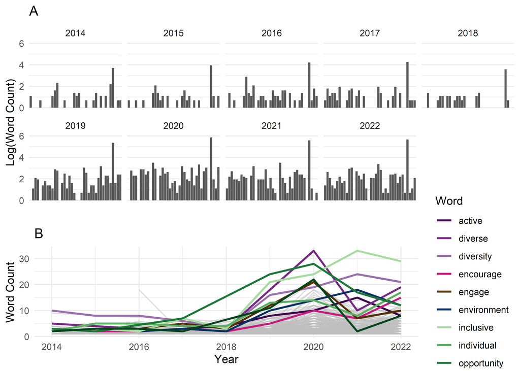

```r
## Code for Bar Chart

# return top 10 distinct words in each year
top_10_distinct <- dei_word_counts %>%
  group_by(Year) %>%
  # return top 10 word counts for each year
  slice(1:10) %>%
  # ungroup by year
  ungroup(Year) %>%
  # return distinct words across the df
  distinct(inclusive_teach_tokens)

# transpose and convert to vector
top_10_distinct <- c(t(top_10_distinct))

# create bar graph over time
 base_bargraph_over_time <- dei_word_counts %>%
  # using only 14.17% DEI related words in dataset
  filter(inclusive_teach_tokens %in% top_10_distinct) %>%
  # log the word counts, due to skewness
  mutate(log_n = log(n)) %>%
  ggplot(aes(inclusive_teach_tokens, log_n)) +
  geom_col() +
  facet_wrap(~Year, nrow = 2) +
  labs(y = "Log(Word Count)") +
  scale_fill_identity(guide = "none") +
  # suppress the x axis
  theme(axis.title.x=element_blank(),
        axis.text.x=element_blank(),
        axis.ticks.x=element_blank()) +
   scale_x_discrete(labels = NULL, breaks = NULL) + labs(title = "A", x = " ") +
  # change the theme
   theme_minimal()

 ## Code for Line Graph

# define the group of words that are going to be highlighted
highlights <- c("opportunity", "inclusive", "diverse", "diversity", "individual", "visual", "engage", "environment", "active", "encourage")
n <- length(highlights)

 # create 'Word' column, which will be used to color the lines
dei_word_counts <- dei_word_counts %>%
  # removing students due to skewness
  filter(inclusive_teach_tokens != "students") %>%
  mutate(Word = if_else(inclusive_teach_tokens %in% highlights, inclusive_teach_tokens, "other"),
         Word = as.factor(Word)) %>%
  mutate(Word = fct_relevel(Word, "other", after = Inf))
# , name_lab = if_else(Year == 2021, inclusive_teach_tokens, NA_character_)

# create line graph s
base_lineplot <- ggplot(
  # filter for counts > 1, for the highlighted words, and the top 40 words across all years
  dei_word_counts %>% filter(n > 1 & Word != "other" & inclusive_teach_tokens %in% top_10_distinct),
  aes(Year, n, Word = inclusive_teach_tokens)
  ) +
  # lines for the non-highlighted words
  geom_line(
    data = dei_word_counts %>% filter(Word == "other"),
    color = "grey75",
    size = .6,
    alpha = .5
    ) +
  # lines for the highlighted words
  geom_line(
    aes(color = Word),
    size = 0.9
   ) +
  # # use ggrepel package to automatically place labels
  # geom_text_repel(
  #   aes(color = Word, label = name_lab),
  #   family = "Lato",
  #   fontface = "bold",
  #   size = 3,
  #   direction = "y",
  #   hjust = 0,
  #   segment.size = .7,
  #   segment.alpha = .5,
  #   segment.linetype = "dotted",
  #   box.padding = .4,
  #   segment.curvature = -0.1,
  #   segment.ncp = 3,
  #   segment.angle = 20,
  #   show.legend = FALSE
  # )  +
  # labels
  labs(title = "B", x = "Year", y = "Word Count") +
  # remove "a" from legend box
  theme(legend.position = "none") +
  # change the theme
  theme_minimal() +
  # remove legend
  guides(fill = "none") +
  # add colorblind safe palette
  scale_color_manual(values = c("#40004b", "#762a83", "#9970ab", "#c51b7d", "#543005", "#053061", "#a6dba0", "#5aae61", "#1b7837", "#00441b"))


# arrange two plots into one column
 require(gridExtra)
 grid.arrange(base_bargraph_over_time, base_lineplot, heights=c(3,2))
```

```r
#plot_grid(base_bargraph_over_time, base_lineplot, labels = c('A', 'B'), label_size = 12)
```

## In Depth Bar Chart of Word Count By Year: Side By Side Comparison

Below you can see the bar chart above more clearly. Click on each tab to see the word frequency for each year. For comparisons purposes, the y axis has the same limits for all the graphs. As above, the word *students* is obscured.

### 2014

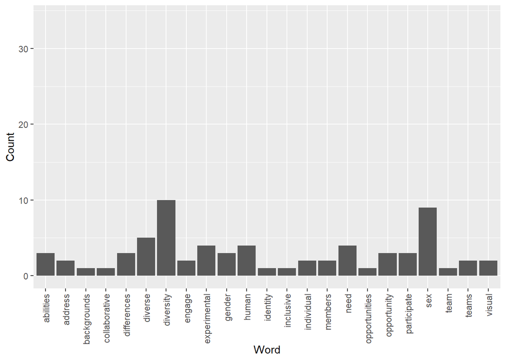

```r
dei_word_counts %>%
  # using only 14.17% DEI related words in dataset
  filter(inclusive_teach_tokens %in% top_10_distinct & Year == 2014) %>%
  # log the word counts, due to skewness
  # mutate(log_n = log(n)) %>%
  ggplot(aes(inclusive_teach_tokens, n))+
  geom_bar(stat = "identity", show.legend = FALSE) +
  # rotate words on x axis
  theme(axis.text.x = element_text(angle = 90, vjust = 0.5, hjust=1)) +
  # set the same y limit for all graphs
  ylim(0,34) +
  # add labels
  labs(x = "Word", y = "Count")
```

### 2015

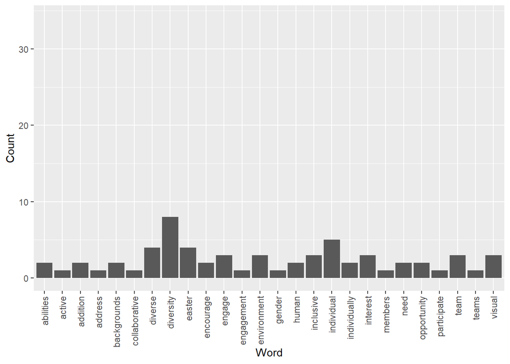

```r
dei_word_counts %>%
  # using only 14.17% DEI related words in dataset
  filter(inclusive_teach_tokens %in% top_10_distinct & Year == 2015) %>%
  # log the word counts, due to skewness
  # mutate(log_n = log(n)) %>%
  ggplot(aes(inclusive_teach_tokens, n))+
  geom_bar(stat = "identity", show.legend = FALSE) +
  # rotate words on x axis
  theme(axis.text.x = element_text(angle = 90, vjust = 0.5, hjust=1)) +
  # set the same y limit for all graphs
  ylim(0,34) +
  # add labels
  labs(x = "Word", y = "Count")
```

### 2016

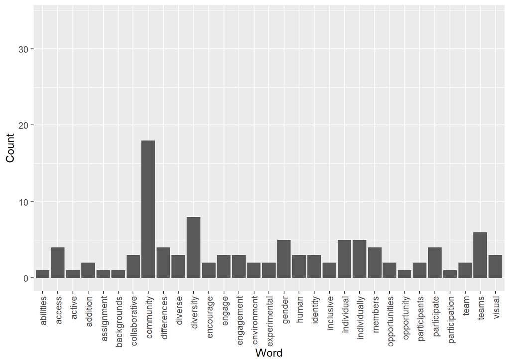

```r
dei_word_counts %>%
  # using only 14.17% DEI related words in dataset
  filter(inclusive_teach_tokens %in% top_10_distinct & Year == 2016) %>%
  # log the word counts, due to skewness
  # mutate(log_n = log(n)) %>%
  ggplot(aes(inclusive_teach_tokens, n))+
  geom_bar(stat = "identity", show.legend = FALSE) +
  # rotate words on x axis
  theme(axis.text.x = element_text(angle = 90, vjust = 0.5, hjust=1)) +
  # set the same y limit for all graphs
  ylim(0,34) +
  # add labels
  labs(x = "Word", y = "Count")
```

### 2017

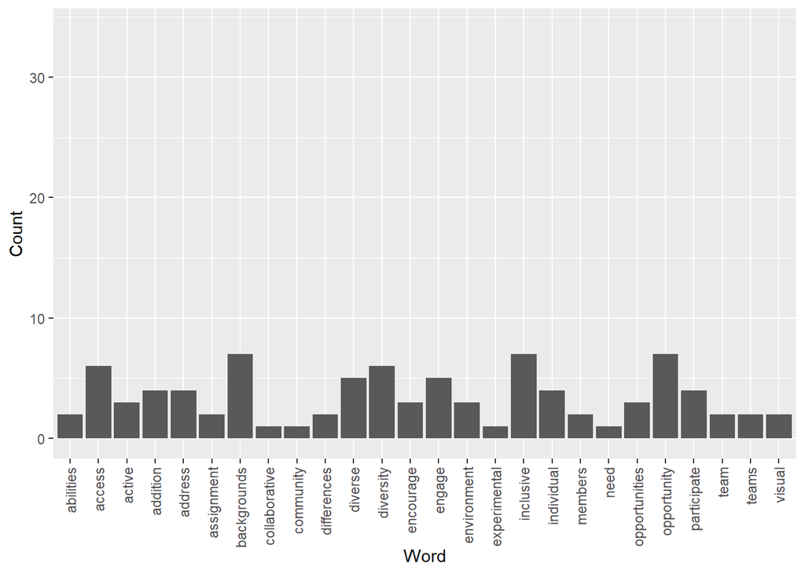

```r
dei_word_counts %>%
  # using only 14.17% DEI related words in dataset
  filter(inclusive_teach_tokens %in% top_10_distinct & Year == 2017) %>%
  # log the word counts, due to skewness
  # mutate(log_n = log(n)) %>%
  ggplot(aes(inclusive_teach_tokens, n))+
  geom_bar(stat = "identity", show.legend = FALSE) +
  # rotate words on x axis
  theme(axis.text.x = element_text(angle = 90, vjust = 0.5, hjust=1)) +
  # set the same y limit for all graphs
  ylim(0,34) +
  # add labels
  labs(x = "Word", y = "Count")
```

### 2018

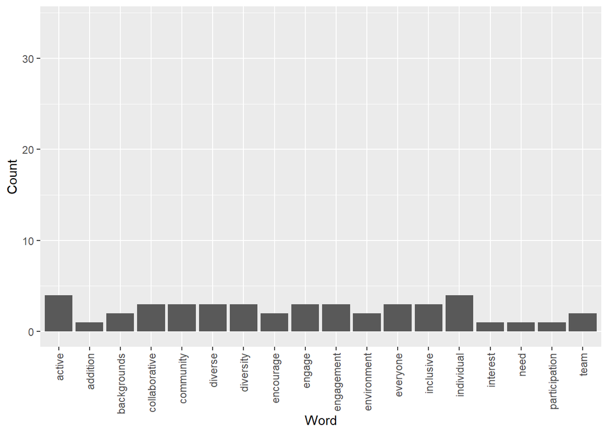

```r
dei_word_counts %>%
  # using only 14.17% DEI related words in dataset
  filter(inclusive_teach_tokens %in% top_10_distinct & Year == 2018) %>%
  # log the word counts, due to skewness
  # mutate(log_n = log(n)) %>%
  ggplot(aes(inclusive_teach_tokens, n))+
  geom_bar(stat = "identity", show.legend = FALSE) +
  # rotate words on x axis
  theme(axis.text.x = element_text(angle = 90, vjust = 0.5, hjust=1)) +
  # set the same y limit for all graphs
  ylim(0,34) +
  # add labels
  labs(x = "Word", y = "Count")
```

### 2019

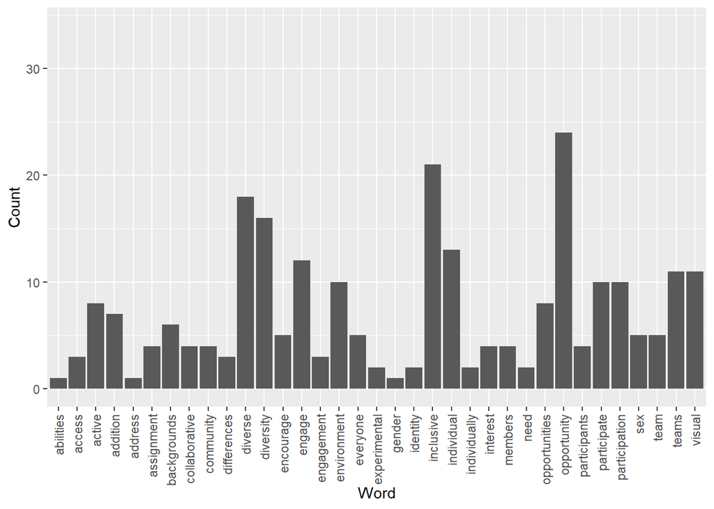

```r
dei_word_counts %>%
  # using only 14.17% DEI related words in dataset
  filter(inclusive_teach_tokens %in% top_10_distinct & Year == 2019) %>%
  # log the word counts, due to skewness
  # mutate(log_n = log(n)) %>%
  ggplot(aes(inclusive_teach_tokens, n))+
  geom_bar(stat = "identity", show.legend = FALSE) +
  # rotate words on x axis
  theme(axis.text.x = element_text(angle = 90, vjust = 0.5, hjust=1)) +
  # set the same y limit for all graphs
  ylim(0,34) +
  # add labels
  labs(x = "Word", y = "Count")
```

### 2020

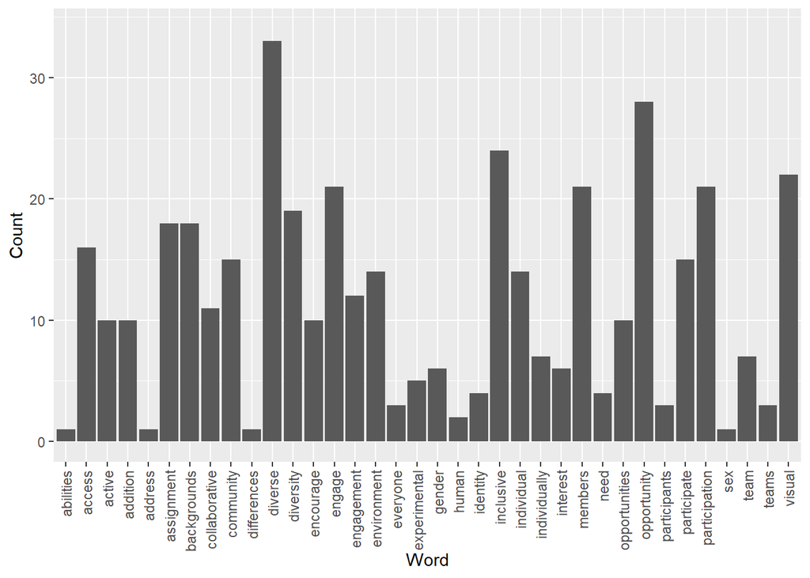

```r
dei_word_counts %>%
  # using only 14.17% DEI related words in dataset
  filter(inclusive_teach_tokens %in% top_10_distinct & Year == 2020) %>%
  # log the word counts, due to skewness
  # mutate(log_n = log(n)) %>%
  ggplot(aes(inclusive_teach_tokens, n))+
  geom_bar(stat = "identity", show.legend = FALSE) +
  # rotate words on x axis
  theme(axis.text.x = element_text(angle = 90, vjust = 0.5, hjust=1)) +
  # set the same y limit for all graphs
  ylim(0,34) +
  # add labels
  labs(x = "Word", y = "Count")
```

### 2021

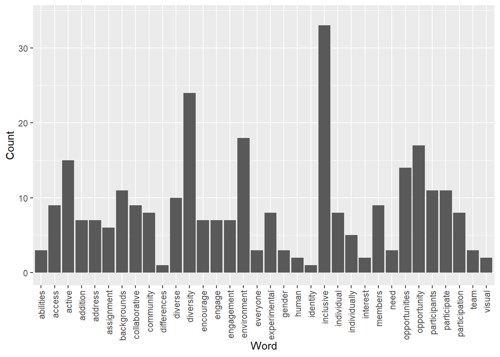

```r
dei_word_counts %>%
  # using only 14.17% DEI related words in dataset
  filter(inclusive_teach_tokens %in% top_10_distinct & Year == 2021) %>%
  # log the word counts, due to skewness
  # mutate(log_n = log(n)) %>%
  ggplot(aes(inclusive_teach_tokens, n))+
  geom_bar(stat = "identity", show.legend = FALSE) +
  # rotate words on x axis
  theme(axis.text.x = element_text(angle = 90, vjust = 0.5, hjust=1)) +
  # set the same y limit for all graphs
  ylim(0,34) +
  # add labels
  labs(x = "Word", y = "Count")
```

### 2022

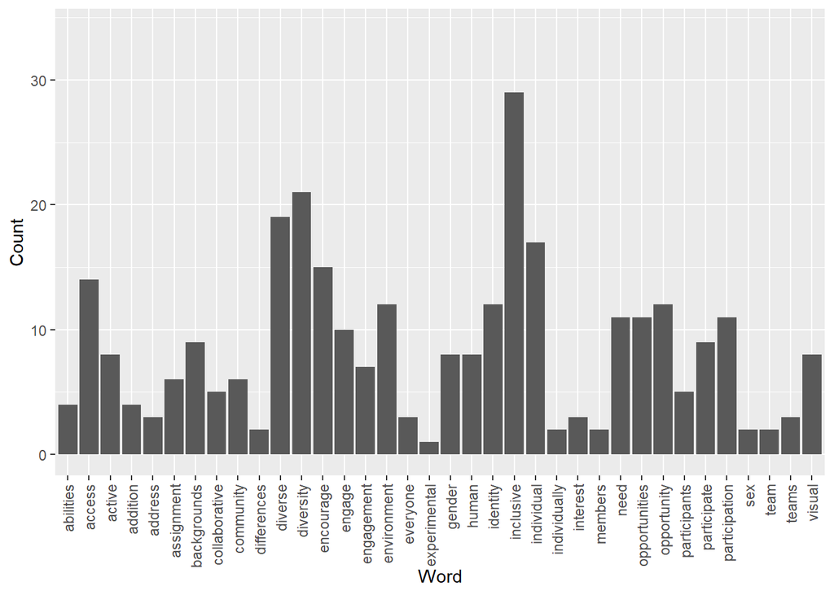

```r
dei_word_counts %>%
  # using only 14.17% DEI related words in dataset
  filter(inclusive_teach_tokens %in% top_10_distinct & Year == 2022) %>%
  # log the word counts, due to skewness
  # mutate(log_n = log(n)) %>%
  ggplot(aes(inclusive_teach_tokens, n))+
  geom_bar(stat = "identity", show.legend = FALSE) +
  # rotate words on x axis
  theme(axis.text.x = element_text(angle = 90, vjust = 0.5, hjust=1)) +
  # set the same y limit for all graphs
  ylim(0,34) +
  # add labels
  labs(x = "Word", y = "Count")
```

## Normalized Word Frequency: The Most Distinctive Words By Year

The normalized word frequency can help us see the “weight” of each word and the words most distinctive for each year. Here we’re printing the idf, which is the [“inverse document frequency, which decreases the weight for commonly used words and increases the weight for words that are not used very much in a collection of documents. This can be combined with term frequency to calculate a term’s tf-idf [the term frequency and idf multiplied together], the frequency of a term adjusted for how rarely it is used. The statistic tf-idf is intended to measure how important a word is to a document in a collection (or corpus) of documents, for example, to one novel in a collection of novels or to one website in a collection of websites”](https://www.tidytextmining.com/tfidf.html).

For comparisons purposes, the y axis has the same limits for all the graphs. We can see which words are the most *unique* to each year and see that the tf-idf becomes uniform after 2018. These results make sense and align with the visuals above.

### 2014

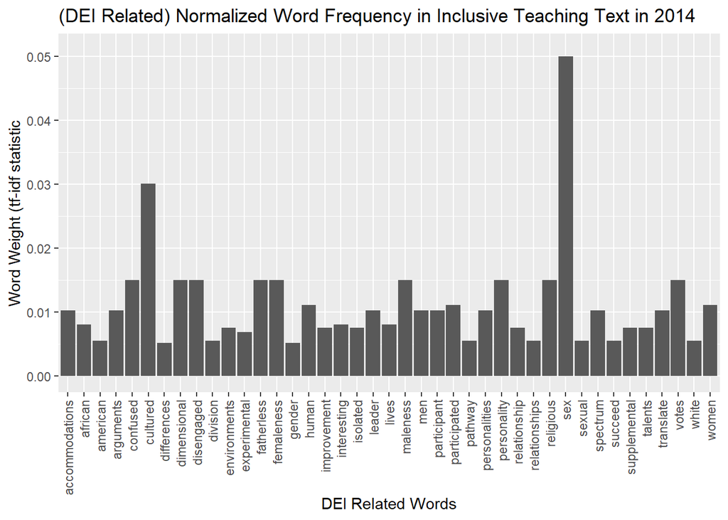

```r
#finding the most distinctive words for each document
dei_word_counts %>%
  # calculate and bind the term frequency and inverse document frequency
  bind_tf_idf(inclusive_teach_tokens, Year, n) %>%
  arrange(desc(tf_idf)) %>%
  filter(Year == 2014) %>%
  # select the top 40
  top_n(40) %>%
  ggplot(aes(inclusive_teach_tokens, tf_idf)) +
  geom_bar(stat = "identity", show.legend = FALSE) +
  # rotate words on x axis
  theme(axis.text.x = element_text(angle = 90, vjust = 0.5, hjust=1)) +
  # label axes
  labs(title = "(DEI Related) Normalized Word Frequency in Inclusive Teaching Text in 2014", x = "DEI Related Words", y = "Word Weight (tf-idf statistic") +
  # set same y limit for all graphs
  ylim(0,0.051)
```

### 2015

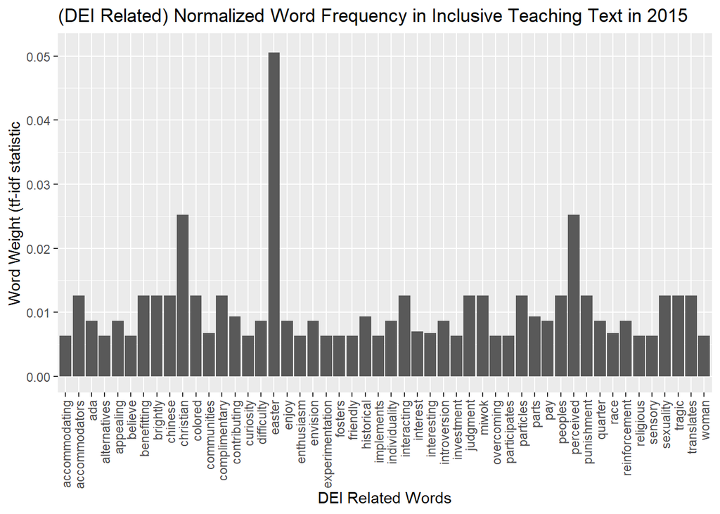

```r
#finding the most distinctive words for each document
dei_word_counts %>%
  # calculate and bind the term frequency and inverse document frequency
  bind_tf_idf(inclusive_teach_tokens, Year, n) %>%
  arrange(desc(tf_idf)) %>%
  filter(Year == 2015) %>%
  # select the top 40
  top_n(40) %>%
  ggplot(aes(inclusive_teach_tokens, tf_idf)) +
  geom_bar(stat = "identity", show.legend = FALSE) +
  # rotate words on x axis
  theme(axis.text.x = element_text(angle = 90, vjust = 0.5, hjust=1)) +
  # label axes
  labs(title = "(DEI Related) Normalized Word Frequency in Inclusive Teaching Text in 2015", x = "DEI Related Words", y = "Word Weight (tf-idf statistic") +
  # set same y limit for all graphs
  ylim(0,0.051)
```

### 2016

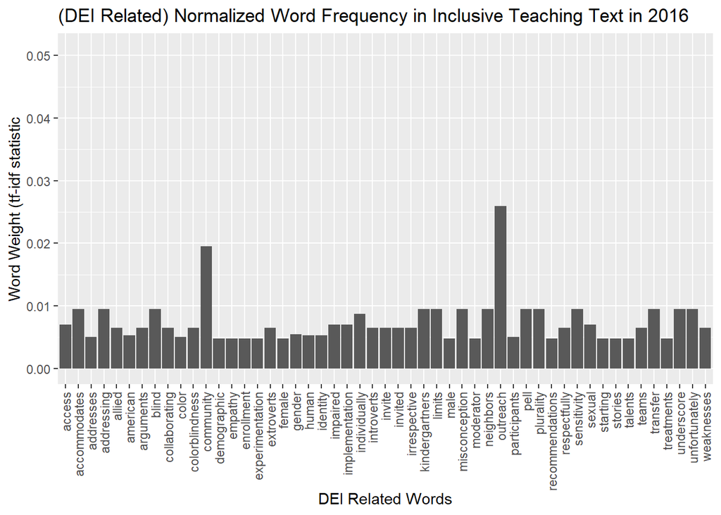

```r
#finding the most distinctive words for each document
dei_word_counts %>%
  # calculate and bind the term frequency and inverse document frequency
  bind_tf_idf(inclusive_teach_tokens, Year, n) %>%
  arrange(desc(tf_idf)) %>%
  filter(Year == 2016) %>%
  # select the top 40
  top_n(40) %>%
  ggplot(aes(inclusive_teach_tokens, tf_idf)) +
  geom_bar(stat = "identity", show.legend = FALSE) +
  # rotate words on x axis
  theme(axis.text.x = element_text(angle = 90, vjust = 0.5, hjust=1)) +
  # label axes
  labs(title = "(DEI Related) Normalized Word Frequency in Inclusive Teaching Text in 2016", x = "DEI Related Words", y = "Word Weight (tf-idf statistic") +
  # set same y limit for all graphs
  ylim(0,0.051)
```

### 2017

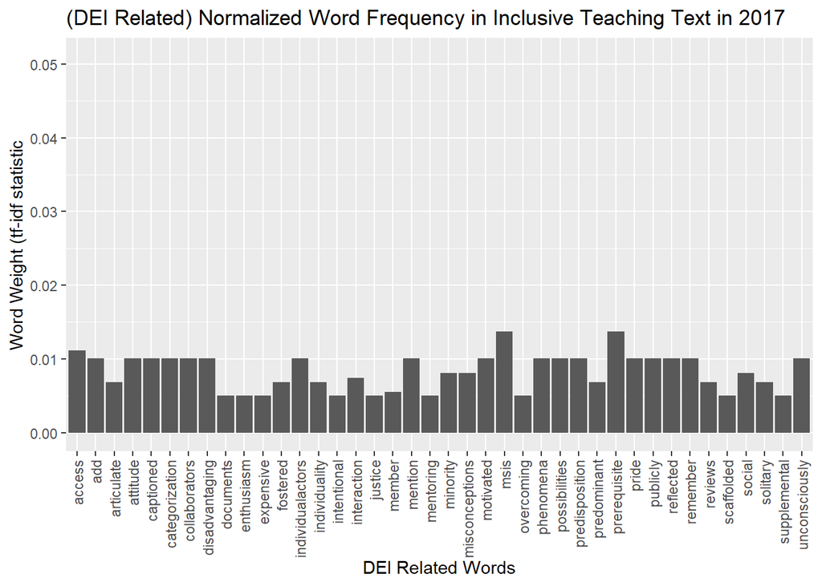

```r
#finding the most distinctive words for each document
dei_word_counts %>%
  # calculate and bind the term frequency and inverse document frequency
  bind_tf_idf(inclusive_teach_tokens, Year, n) %>%
  arrange(desc(tf_idf)) %>%
  filter(Year == 2017) %>%
  # select the top 40
  top_n(40) %>%
  ggplot(aes(inclusive_teach_tokens, tf_idf)) +
  geom_bar(stat = "identity", show.legend = FALSE) +
  # rotate words on x axis
  theme(axis.text.x = element_text(angle = 90, vjust = 0.5, hjust=1)) +
  # label axes
  labs(title = "(DEI Related) Normalized Word Frequency in Inclusive Teaching Text in 2017", x = "DEI Related Words", y = "Word Weight (tf-idf statistic") +
  # set same y limit for all graphs
  ylim(0,0.051)
```

### 2018

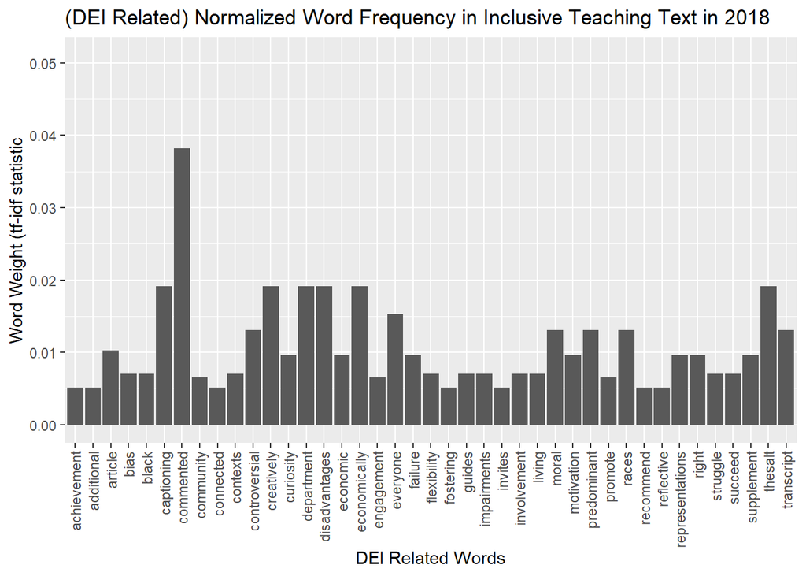

```r
#finding the most distinctive words for each document
dei_word_counts %>%
  # calculate and bind the term frequency and inverse document frequency
  bind_tf_idf(inclusive_teach_tokens, Year, n) %>%
  arrange(desc(tf_idf)) %>%
  filter(Year == 2018) %>%
  # select the top 40
  top_n(40) %>%
  ggplot(aes(inclusive_teach_tokens, tf_idf)) +
  geom_bar(stat = "identity", show.legend = FALSE) +
  # rotate words on x axis
  theme(axis.text.x = element_text(angle = 90, vjust = 0.5, hjust=1)) +
  # label axes
  labs(title = "(DEI Related) Normalized Word Frequency in Inclusive Teaching Text in 2018", x = "DEI Related Words", y = "Word Weight (tf-idf statistic") +
  # set same y limit for all graphs
  ylim(0,0.051)
```

### 2019

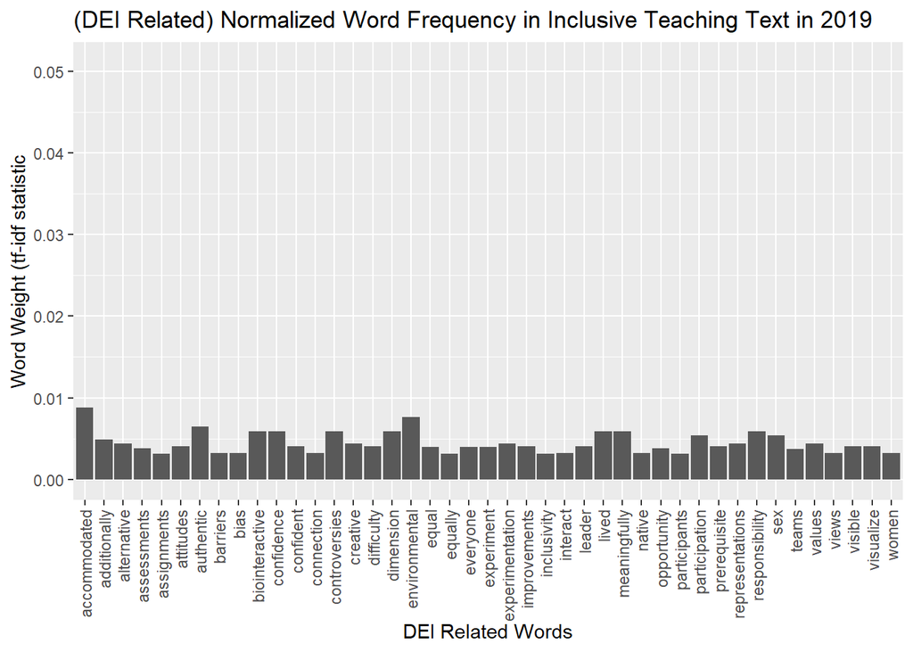

```r
#finding the most distinctive words for each document
dei_word_counts %>%
  # calculate and bind the term frequency and inverse document frequency
  bind_tf_idf(inclusive_teach_tokens, Year, n) %>%
  arrange(desc(tf_idf)) %>%
  filter(Year == 2019) %>%
  # select the top 40
  top_n(40) %>%
  ggplot(aes(inclusive_teach_tokens, tf_idf)) +
  geom_bar(stat = "identity", show.legend = FALSE) +
  # rotate words on x axis
  theme(axis.text.x = element_text(angle = 90, vjust = 0.5, hjust=1)) +
  # label axes
  labs(title = "(DEI Related) Normalized Word Frequency in Inclusive Teaching Text in 2019", x = "DEI Related Words", y = "Word Weight (tf-idf statistic") +
  # set same y limit for all graphs
  ylim(0,0.051)
```

### 2020

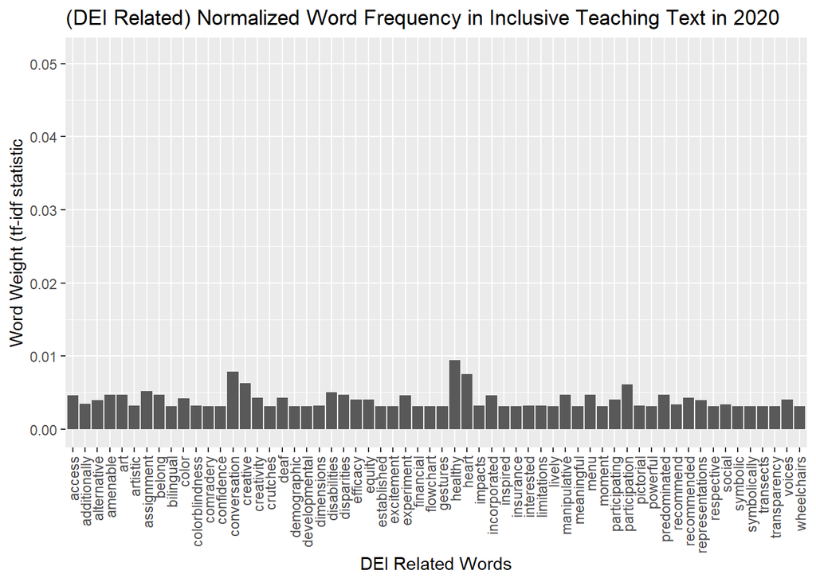

```r
#finding the most distinctive words for each document
dei_word_counts %>%
  # calculate and bind the term frequency and inverse document frequency
  bind_tf_idf(inclusive_teach_tokens, Year, n) %>%
  arrange(desc(tf_idf)) %>%
  filter(Year == 2020) %>%
  # select the top 40
  top_n(40) %>%
  ggplot(aes(inclusive_teach_tokens, tf_idf)) +
  geom_bar(stat = "identity", show.legend = FALSE) +
  # rotate words on x axis
  theme(axis.text.x = element_text(angle = 90, vjust = 0.5, hjust=1)) +
  # label axes
  labs(title = "(DEI Related) Normalized Word Frequency in Inclusive Teaching Text in 2020", x = "DEI Related Words", y = "Word Weight (tf-idf statistic") +
  # set same y limit for all graphs
  ylim(0,0.051)
```

### 2021

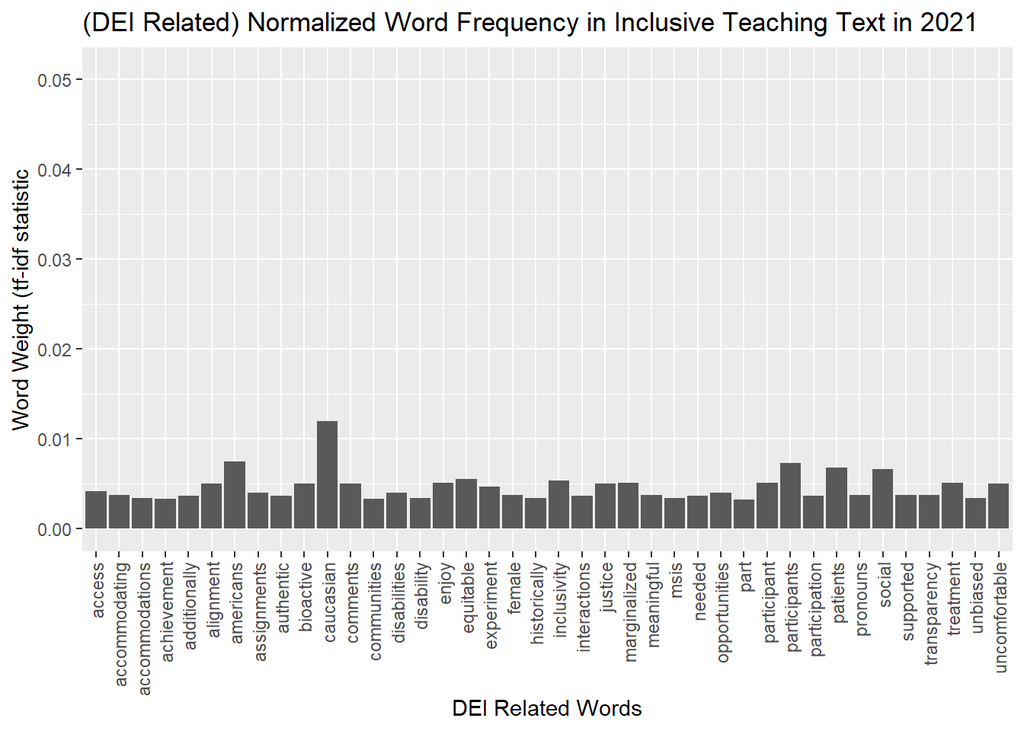

```r
#finding the most distinctive words for each document
dei_word_counts %>%
  # calculate and bind the term frequency and inverse document frequency
  bind_tf_idf(inclusive_teach_tokens, Year, n) %>%
  arrange(desc(tf_idf)) %>%
  filter(Year == 2021) %>%
  # select the top 40
  top_n(40) %>%
  ggplot(aes(inclusive_teach_tokens, tf_idf)) +
  geom_bar(stat = "identity", show.legend = FALSE) +
  # rotate words on x axis
  theme(axis.text.x = element_text(angle = 90, vjust = 0.5, hjust=1)) +
  # label axes
  labs(title = "(DEI Related) Normalized Word Frequency in Inclusive Teaching Text in 2021", x = "DEI Related Words", y = "Word Weight (tf-idf statistic") +
  # set same y limit for all graphs
  ylim(0,0.051)
```

### 2022

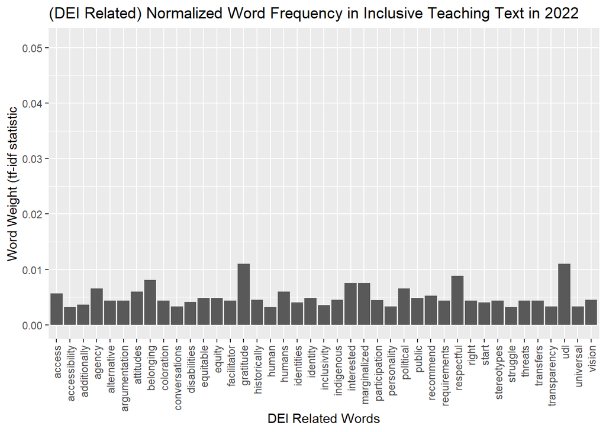

```r
#finding the most distinctive words for each document
dei_word_counts %>%
  # calculate and bind the term frequency and inverse document frequency
  bind_tf_idf(inclusive_teach_tokens, Year, n) %>%
  arrange(desc(tf_idf)) %>%
  filter(Year == 2022) %>%
  # select the top 40
  top_n(40) %>%
  ggplot(aes(inclusive_teach_tokens, tf_idf)) +
  geom_bar(stat = "identity", show.legend = FALSE) +
  # rotate words on x axis
  theme(axis.text.x = element_text(angle = 90, vjust = 0.5, hjust=1)) +
  # label axes
  labs(title = "(DEI Related) Normalized Word Frequency in Inclusive Teaching Text in 2022", x = "DEI Related Words", y = "Word Weight (tf-idf statistic") +
  # set same y limit for all graphs
  ylim(0,0.051)
```

# Exploratory Data Analysis: The Most DEI Related Content

Which articles and years has the highest proportion of DEI related *words* and *phrases*? How does this proportion change?

Looking at proportions gives us an idea of how many DEI words are being used and if there is a change over time. Below, I calculate the number of DEI related words for each article and year. Then, I divided those numbers by the total amount of words for each article and year to get a proportion. Based on what Yuhao calculated in section Paper-wise statistics, we already have a column which gives the total amount of DEI related words for each article, and the ratio. I use this column to calculate the total amount of DEI related words for each *year*. Since I want to calculate the total amount of words (including stopwords), for 2-word and 3-word phrases I repeated some of my analyses done in the *Data Cleaning* RMD. I couldn’t use the `rios_data_tokenized2`, and `rios_data_tokenized3` dataframes, since they’re cleaned and don’t contain stopwords. The total amount of words and DEI related words I calculate are not *distinct* and include duplicates.

```r
# calculate the total amount of DEI related words for each YEAR
totaldeiyear <- rios_data %>%
  # group by year
  group_by(Year) %>%
  # select the `DEI Word Count` column
  select(13) %>%
  # add the DEI Word Count column for each year
  summarise(totaldei_by_year = sum(`DEI Word count`, na.rm = FALSE))

# calculate the total amount of DEI related words for each ARTICLE

# rios_data %>%
#   select(11, 13)

# calculate the total amount of words in each YEAR
totalwordsyear <- rios_data %>%
  # group by year
  group_by(Year) %>%
  # select the `Word Count` column
  select(9) %>%
  # add the Word Count column for each year
  summarise(total_by_year = sum(`Word Count of Inclusive Teaching?`))

# calculate the total amount of words in each ARTICLE

# rios_data %>%
#   select(9)


# 2-word phrases

# calculate the total amount of DEI related 2-word phrases for each YEAR
total2deiyear <- rios_data_tokenized2 %>%
  # filter for words labeled as DEI related
  filter(dei_related == "TRUE") %>%
  # group by year
  group_by(Year) %>%
  # count the number of times each article appears
  count(article_num) %>%
  # add the number of times the article appears for each year
  summarise(totaldei_by_year = sum(n))

# calculate the total amount of DEI related 2-word phrases for each ARTICLE
total2deiarticle <- rios_data_tokenized2 %>%
  # filter for words labeled as DEI related
  filter(dei_related == "TRUE") %>%
  # group by article no. & year
  group_by(article_num, Year) %>%
  # count the number of times each article appears
  count(article_num)

# store unnecessary punctuation or digits in a vector for removal
strings <- c("[:punct:]", "[:digit:]","\\(","\\)")

# calculate the total amount of 2-word phrases in each YEAR
total2wordsyear <- rios_data %>%
  # split the text from the `inclusive teaching description` column into a two-token-per-row format
  unnest_tokens(it_tokens_2w, `Inclusive Teaching Description`, token = "ngrams", n = 2)  %>%
  # remove ~1,390 rows of punctuation and digits
  filter(!str_detect(it_tokens_2w, paste(strings, collapse = "|"))) %>%
  # group by year
  group_by(Year) %>%
  # count the total in each year
  tally()

# calculate the total amount of 2-word phrases in each ARTICLE
total2wordsarticle <-  rios_data %>%
  # split the text from the `inclusive teaching description` column into a two-token-per-row format
  unnest_tokens(it_tokens_2w, `Inclusive Teaching Description`, token = "ngrams", n = 2)  %>%
  # remove ~1,390 rows of punctuation and digits
  filter(!str_detect(it_tokens_2w, paste(strings, collapse = "|"))) %>%
  # group by article no.
  group_by(article_num) %>%
  # count the total in each article
  tally()


# same code as above, but for 3-word phrases

# calculate the total amount of DEI related 3-word phrases for each YEAR
total3deiyear <- rios_data_tokenized3 %>%
  # filter for words labeled as DEI related
  filter(dei_related == "TRUE") %>%
  # group by year
  group_by(Year) %>%
  # count the number of times each article appears
  count(article_num) %>%
  # add the number of times the article appears for each year
  summarise(totaldei_by_year = sum(n))

# calculate the total amount of DEI related 3-word phrases for each ARTICLE
total3deiarticle <- rios_data_tokenized3 %>%
  # filter for words labeled as DEI related
  filter(dei_related == "TRUE") %>%
  # group by article no. & year
  group_by(article_num, Year) %>%
  # count the number of times each article appears
  count(article_num)

# calculate the total amount of 3-word phrases in each YEAR
total3wordsyear <- rios_data %>%
  # split the text from the `inclusive teaching description` column into a three-token-per-row format
  unnest_tokens(it_tokens_3w, `Inclusive Teaching Description`, token = "ngrams", n = 3)  %>%
  # remove ~1,994 rows of punctuation and digits
  filter(!str_detect(it_tokens_3w, paste(strings, collapse = "|"))) %>%
  # group by year
  group_by(Year) %>%
  # count the total in each year
  tally()

# calculate the total amount of 3-word phrases in each ARTICLE
total3wordsarticle <- rios_data %>%
  # split the text from the `inclusive teaching description` column into a three-token-per-row format
  unnest_tokens(it_tokens_3w, `Inclusive Teaching Description`, token = "ngrams", n = 3)  %>%
  # remove ~1,994 rows of punctuation and digits
  filter(!str_detect(it_tokens_3w, paste(strings, collapse = "|"))) %>%
  # group by article no.
  group_by(article_num) %>%
  # count the total in each article
  tally()
```

## Box Plots

Here’s a box plot of the ratio of DEI related words, 2-word phrases and 3-word phrases by article over time with a table which goes more in depth of the statistics shown on the boxplot for each year. For some reason, the mean in 2014 or 2015 is the highest across 1 word, 2-word and 3 phrases. However, the ratio shifts and decreases as we move from 1 words to 3 words. The average ratio is slightly higher from the years 2019 to 2022 for 1 word (0.135 vs. 0.134) and 2 word phrases (0.0745 vs. 0.0723).

### 1 word

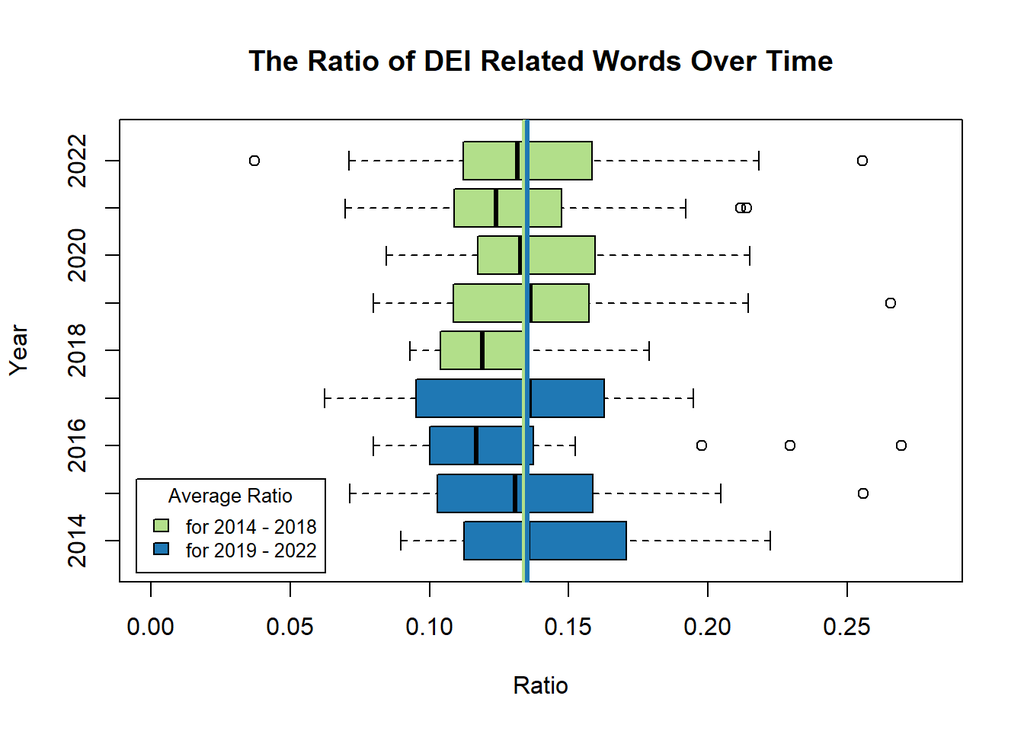

```r
df1 <- rios_data %>%
  select(4, 9, 11, 13, 14) %>%
  # turn the ratio into a decimal
  mutate(`DEI_Words_%` = `DEI_Words_%`/100) %>%
  group_by(Year)  %>%
  rename("Article Number" = "article_num",
         "Total DEI By Article" = "DEI Word count",
         "Total By Article" = "Word Count of Inclusive Teaching?",
         "DEI Ratio 1w" = "DEI_Words_%")

# create a function which creates a boxplot
ratioboxplot <- function(){
  # factor years to reorder from oldest to most recent (to be consistent with table below)
  rios_data$Year <- factor(rios_data$Year , levels=c("2022", "2021", "2020", "2019", "2018", "2017", "2016", "2015", "2014"))

  # create box plot and store in function
  boxplot(df1$`DEI Ratio 1w` ~ df1$Year,
          df1,
          xlab = "Ratio",
          ylab = "Year",
          main = "The Ratio of DEI Related Words Over Time",
          horizontal = TRUE,
          # color groups (color blind safe colors) based on the shift (2014-2018 and 2019-2022)
          col = c("#1f78b4", "#1f78b4", "#1f78b4", "#1f78b4", "#b2df8a","#b2df8a", "#b2df8a", "#b2df8a", "#b2df8a"),
          ylim = c(0,0.28))

  # color and impose horizontal line of 2014 - 2018 group average ratio
  abline(v = 0.134, col = "#b2df8a", lty = "solid", lwd = 3)

  # color and impose horizontal line of 2019 - 2022 group average ratio
  abline(v = 0.135, col = "#1f78b4",lty = "solid", lwd = 3)

  # impose legend which explain horizontal lines
  legend("bottomleft", inset=.02, title="Average Ratio", c("for 2014 - 2018","for 2019 - 2022"), fill=c("#b2df8a", "#1f78b4"), horiz=FALSE, cex=0.8)

  # unfactor years
  rios_data$Year <-  unfactor(rios_data$Year)
}

# call
ratioboxplot()
```

```r
skim_table <- df1 %>%
  # group by year
  group_by(Year) %>%
  # present an overview only on the 'DEI Ratio' column
  skim(starts_with("DEI")) %>%
  # remove the variable and completion rate column
  select(3,6:13)  %>%
  # round the mean and sd columns; calculate the variance
  mutate(numeric.mean = round(numeric.mean, digits = 2), numeric.sd = round(numeric.sd, digits = 2), variance = (numeric.sd)^2) %>%
  # rename all columns
  rename("Mean" = "numeric.mean",
         "SD" = "numeric.sd",
         "Variance" = "variance",
         "Min" = "numeric.p0",
         "25 Q" = "numeric.p25",
         "Median" = "numeric.p50",
         "75 Q" = "numeric.p75",
         "Max" = "numeric.p100",
         "Histogram" = "numeric.hist")


df1 %>%
  # count the number of articles for each YEAR
  count(Year) %>%
  # rename column
  rename("# of Articles" = "n") %>%
  # combine with skim table made above
  full_join(skim_table, by = "Year") %>%
  # turn this table into a nicely formatted table
  kable() %>%
  kable_minimal()
```

| Year | # of Articles | Mean | SD | Min | 25 Q | Median | 75 Q | Max | Histogram | Variance |
| --- | --- | --- | --- | --- | --- | --- | --- | --- | --- | --- |
| 2014 | 13 | 0.15 | 0.04 | 0.0896552 | 0.1125000 | 0.1353383 | 0.1705426 | 0.2222222 | ▇▆▃▃▃ | 0.0016 |
| 2015 | 14 | 0.14 | 0.05 | 0.0714286 | 0.1029995 | 0.1307815 | 0.1578407 | 0.2558140 | ▇▅▆▂▂ | 0.0025 |
| 2016 | 20 | 0.13 | 0.05 | 0.0800000 | 0.1000000 | 0.1169028 | 0.1345515 | 0.2692308 | ▇▆▁▂▁ | 0.0025 |
| 2017 | 19 | 0.13 | 0.04 | 0.0625000 | 0.0951871 | 0.1358025 | 0.1628226 | 0.1948052 | ▆▆▃▇▆ | 0.0016 |
| 2018 | 10 | 0.12 | 0.02 | 0.0930233 | 0.1059850 | 0.1190087 | 0.1331414 | 0.1789474 | ▆▇▃▁▂ | 0.0004 |
| 2019 | 42 | 0.14 | 0.04 | 0.0800000 | 0.1099308 | 0.1363184 | 0.1566168 | 0.2656250 | ▇▇▆▁▁ | 0.0016 |
| 2020 | 51 | 0.14 | 0.03 | 0.0846395 | 0.1174173 | 0.1327434 | 0.1593479 | 0.2149533 | ▅▇▅▂▂ | 0.0009 |
| 2021 | 40 | 0.13 | 0.04 | 0.0697674 | 0.1089417 | 0.1239246 | 0.1470740 | 0.2137405 | ▃▇▅▂▂ | 0.0016 |
| 2022 | 47 | 0.13 | 0.04 | 0.0371901 | 0.1120109 | 0.1314554 | 0.1584063 | 0.2553191 | ▁▇▇▃▁ | 0.0016 |

### 2 word Phrases

For article numbers 69 and 95, there aren’t any DEI related 2-word phrases, which is why we’re seeing 2 NA’s in the table below.

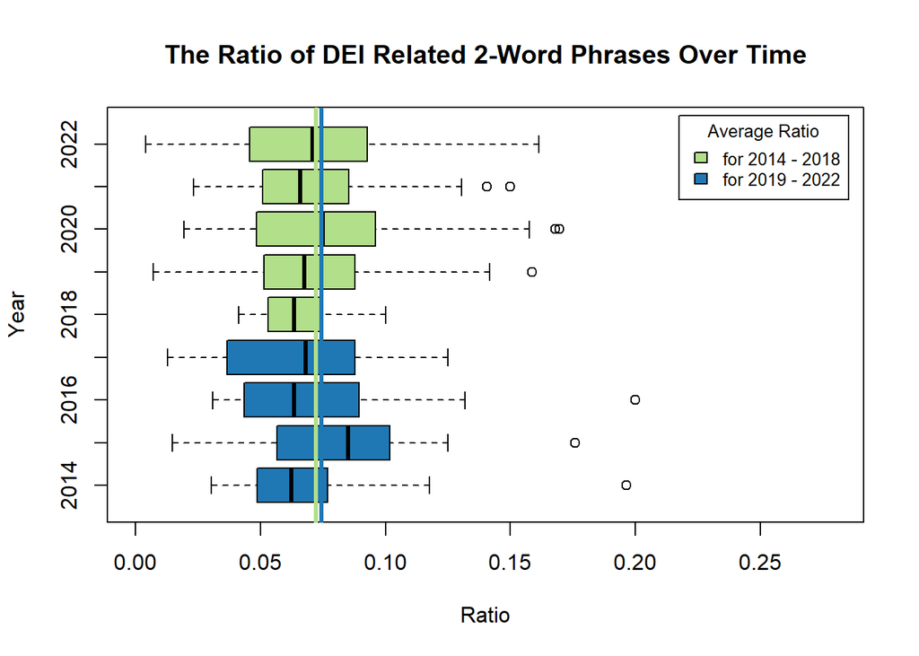

```r
df2 <- total2deiarticle %>%
  full_join(total2wordsarticle, by = c("article_num")) %>%
  # calculate the ratio of DEI "relatedness"
  mutate(ratio = n.x/n.y) %>%
  group_by(Year)  %>%
  rename("Article Number" = "article_num",
         "Total DEI By Article" = "n.x",
         "Total By Article" = "n.y",
         "DEI Ratio 2w" = "ratio")


# create a function which creates a boxplot
ratio2boxplot <- function(){
  # factor years to reorder from oldest to most recent (to be consistent with table below)
  rios_data$Year <- factor(rios_data$Year , levels=c("2022", "2021", "2020", "2019", "2018", "2017", "2016", "2015", "2014"))

  # create box plot and store in function
  boxplot(df2$`DEI Ratio 2w` ~ df2$Year,
          df2,
          xlab = "Ratio",
          ylab = "Year",
          main = "The Ratio of DEI Related 2-Word Phrases Over Time",
          horizontal = TRUE,
          # color groups (color blind safe colors) based on the shift (2014-2018 and 2019-2022)
          col = c("#1f78b4", "#1f78b4", "#1f78b4", "#1f78b4", "#b2df8a","#b2df8a", "#b2df8a", "#b2df8a", "#b2df8a"),
          ylim = c(0,0.28))

  # color and impose horizontal line of 2014 - 2018 group average ratio
  abline(v = 0.0723, col = "#b2df8a", lty = "solid", lwd = 3)

  # color and impose horizontal line of 2019 - 2022 group average ratio
  abline(v = 0.0745, col = "#1f78b4",lty = "solid", lwd = 3)

  # impose legend which explain horizontal lines
  legend("topright", inset=.02, title="Average Ratio", c("for 2014 - 2018","for 2019 - 2022"), fill=c("#b2df8a", "#1f78b4"), horiz=FALSE, cex=0.8)

  # unfactor years
  rios_data$Year <-  unfactor(rios_data$Year)
}

# call
ratio2boxplot()
```

```r
skim_table2 <- df2 %>%
  # group by year
  group_by(Year) %>%
  # present an overview only on the 'DEI Ratio' column
  skim(starts_with("DEI")) %>%
  # remove the variable and completion rate column
  select(3,6:13)  %>%
  # round the mean and sd columns; calculate the variance
  mutate(numeric.mean = round(numeric.mean, digits = 2), numeric.sd = round(numeric.sd, digits = 2), variance = (numeric.sd)^2) %>%
  # rename all columns
  rename("Mean" = "numeric.mean",
         "SD" = "numeric.sd",
         "Variance" = "variance",
         "Min" = "numeric.p0",
         "25 Q" = "numeric.p25",
         "Median" = "numeric.p50",
         "75 Q" = "numeric.p75",
         "Max" = "numeric.p100",
         "Histogram" = "numeric.hist")


df2 %>%
  # count the number of articles for each YEAR
  count(Year) %>%
  # rename column
  rename("# of Articles" = "n") %>%
  # combine with skim table made above
  full_join(skim_table2, by = "Year") %>%
  # turn this table into a nicely formatted table
  kable() %>%
  kable_minimal()
```

| Year | # of Articles | Mean | SD | Min | 25 Q | Median | 75 Q | Max | Histogram | Variance |
| --- | --- | --- | --- | --- | --- | --- | --- | --- | --- | --- |
| 2014 | 13 | 0.07 | 0.04 | 0.0303030 | 0.0487805 | 0.0625000 | 0.0769231 | 0.1964286 | ▇▃▁▁▁ | 0.0016 |
| 2015 | 14 | 0.08 | 0.04 | 0.0149254 | 0.0604103 | 0.0850796 | 0.1009625 | 0.1758242 | ▆▇▇▃▂ | 0.0016 |
| 2016 | 20 | 0.07 | 0.04 | 0.0310078 | 0.0439220 | 0.0633916 | 0.0872673 | 0.2000000 | ▇▃▂▁▁ | 0.0016 |
| 2017 | 19 | 0.07 | 0.03 | 0.0129870 | 0.0365984 | 0.0681818 | 0.0878339 | 0.1250000 | ▅▂▇▃▃ | 0.0009 |
| 2018 | 9 | 0.06 | 0.02 | 0.0412371 | 0.0529412 | 0.0635838 | 0.0744681 | 0.1000000 | ▇▇▅▁▂ | 0.0004 |
| 2019 | 41 | 0.07 | 0.03 | 0.0070922 | 0.0514706 | 0.0675676 | 0.0877193 | 0.1587302 | ▂▇▆▂▁ | 0.0009 |
| 2020 | 51 | 0.08 | 0.04 | 0.0195312 | 0.0485009 | 0.0748899 | 0.0959116 | 0.1696429 | ▆▇▅▂▂ | 0.0016 |
| 2021 | 40 | 0.07 | 0.03 | 0.0232558 | 0.0510878 | 0.0657895 | 0.0846117 | 0.1500000 | ▅▇▆▂▂ | 0.0009 |
| 2022 | 47 | 0.07 | 0.04 | 0.0041841 | 0.0457393 | 0.0707547 | 0.0927511 | 0.1612903 | ▂▇▆▃▂ | 0.0016 |
| NA | 2 | NaN | NA | NA | NA | NA | NA | NA |  | NA |

### 3 word Phrases

For article numbers 5, 59, 69, 95, 128, 140, 142, 219, and 247, there aren’t any DEI related 3-word phrases, which is why we’re seeing 9 NA’s in the table below.

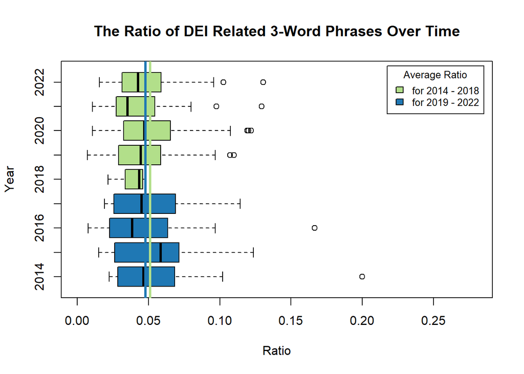

```r
df3 <- total3deiarticle %>%
  full_join(total3wordsarticle, by = c("article_num")) %>%
  # calculate the ratio of DEI "relatedness"
  mutate(ratio = n.x/n.y) %>%
  group_by(Year)  %>%
  rename("Article Number" = "article_num",
         "Total DEI By Article" = "n.x",
         "Total By Article" = "n.y",
         "DEI Ratio 3w" = "ratio")


# create a function which creates a boxplot
ratio3boxplot <- function(){
  # factor years to reorder from oldest to most recent (to be consistent with table below)
  rios_data$Year <- factor(rios_data$Year , levels=c("2022", "2021", "2020", "2019", "2018", "2017", "2016", "2015", "2014"))

  # create box plot and store in function
  boxplot(df3$`DEI Ratio 3w` ~ df3$Year,
          df3,
          xlab = "Ratio",
          ylab = "Year",
          main = "The Ratio of DEI Related 3-Word Phrases Over Time",
          horizontal = TRUE,
          # color groups (color blind safe colors) based on the shift (2014-2018 and 2019-2022)
          col = c("#1f78b4", "#1f78b4", "#1f78b4", "#1f78b4", "#b2df8a","#b2df8a", "#b2df8a", "#b2df8a", "#b2df8a"),
          ylim = c(0,0.28))

  # color and impose horizontal line of 2014 - 2018 group average ratio
  abline(v = 0.0512, col = "#b2df8a", lty = "solid", lwd = 3)

  # color and impose horizontal line of 2019 - 2022 group average ratio
  abline(v = 0.0480, col = "#1f78b4",lty = "solid", lwd = 3)

  # impose legend which explain horizontal lines
  legend("topright", inset=.02, title="Average Ratio", c("for 2014 - 2018","for 2019 - 2022"), fill=c("#b2df8a", "#1f78b4"), horiz=FALSE, cex=0.8)

  # unfactor years
  rios_data$Year <-  unfactor(rios_data$Year)
}

# call
ratio3boxplot()
```

```r
skim_table3 <- df3 %>%
  # group by year
  group_by(Year) %>%
  # present an overview only on the 'DEI Ratio' column
  skim(starts_with("DEI")) %>%
  # remove the variable and completion rate column
  select(3,6:13)  %>%
  # round the mean and sd columns; calculate the variance
  mutate(numeric.mean = round(numeric.mean, digits = 2), numeric.sd = round(numeric.sd, digits = 2), variance = (numeric.sd)^2) %>%
  # rename all columns
  rename("Mean" = "numeric.mean",
         "SD" = "numeric.sd",
         "Variance" = "variance",
         "Min" = "numeric.p0",
         "25 Q" = "numeric.p25",
         "Median" = "numeric.p50",
         "75 Q" = "numeric.p75",
         "Max" = "numeric.p100",
         "Histogram" = "numeric.hist")


df3 %>%
  # count the number of articles for each YEAR
  count(Year) %>%
  # rename column
  rename("# of Articles" = "n") %>%
  # combine with skim table made above
  full_join(skim_table3, by = "Year") %>%
  # turn this table into a nicely formatted table
  kable() %>%
  kable_minimal()
```

| Year | # of Articles | Mean | SD | Min | 25 Q | Median | 75 Q | Max | Histogram | Variance |
| --- | --- | --- | --- | --- | --- | --- | --- | --- | --- | --- |
| 2014 | 12 | 0.06 | 0.05 | 0.0224215 | 0.0309524 | 0.0464226 | 0.0651135 | 0.2000000 | ▇▂▁▁▁ | 0.0025 |
| 2015 | 14 | 0.06 | 0.03 | 0.0151515 | 0.0282596 | 0.0586629 | 0.0708128 | 0.1235955 | ▇▃▇▂▂ | 0.0009 |
| 2016 | 20 | 0.05 | 0.04 | 0.0078125 | 0.0230818 | 0.0384868 | 0.0595238 | 0.1666667 | ▇▃▃▁▁ | 0.0016 |
| 2017 | 18 | 0.05 | 0.03 | 0.0190476 | 0.0265491 | 0.0451999 | 0.0679579 | 0.1142857 | ▇▆▂▃▁ | 0.0009 |
| 2018 | 9 | 0.04 | 0.01 | 0.0215054 | 0.0336391 | 0.0434783 | 0.0459770 | 0.0473373 | ▂▂▃▁▇ | 0.0001 |
| 2019 | 41 | 0.05 | 0.02 | 0.0071942 | 0.0289855 | 0.0445545 | 0.0585480 | 0.1098901 | ▆▇▆▂▂ | 0.0004 |
| 2020 | 48 | 0.05 | 0.03 | 0.0107527 | 0.0335544 | 0.0469337 | 0.0653625 | 0.1219512 | ▅▇▅▂▂ | 0.0009 |
| 2021 | 40 | 0.04 | 0.02 | 0.0106383 | 0.0275901 | 0.0353875 | 0.0544172 | 0.1293103 | ▇▅▂▁▁ | 0.0004 |
| 2022 | 45 | 0.05 | 0.03 | 0.0157480 | 0.0314465 | 0.0426829 | 0.0588235 | 0.1304348 | ▇▇▂▁▁ | 0.0009 |
| NA | 9 | NaN | NA | NA | NA | NA | NA | NA |  | NA |

## Line graphs

Below are line graphs of what was presented above.

### 1 word Phrase

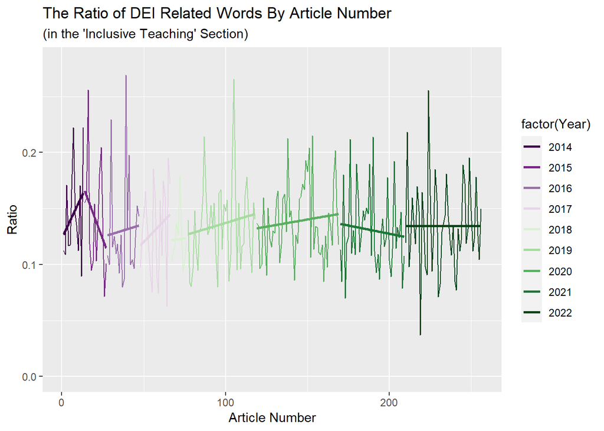

```r
df1 %>%
  ggplot(aes(`Article Number`, `DEI Ratio 1w`, colour = factor(Year))) +
  geom_line() +
  ylim(0,0.28) +
  labs(y = "Ratio", title = "The Ratio of DEI Related Words By Article Number", subtitle = "(in the 'Inclusive Teaching' Section)", x = "Article Number") +
  geom_smooth(method=lm, se=FALSE) +
  scale_discrete_manual(aesthetics = "colour", values = c("#40004b", "#762a83", "#9970ab", "#e7d4e8", "#d9f0d3", "#a6dba0", "#5aae61", "#1b7837", "#00441b"))
```

### 2 word Phrases

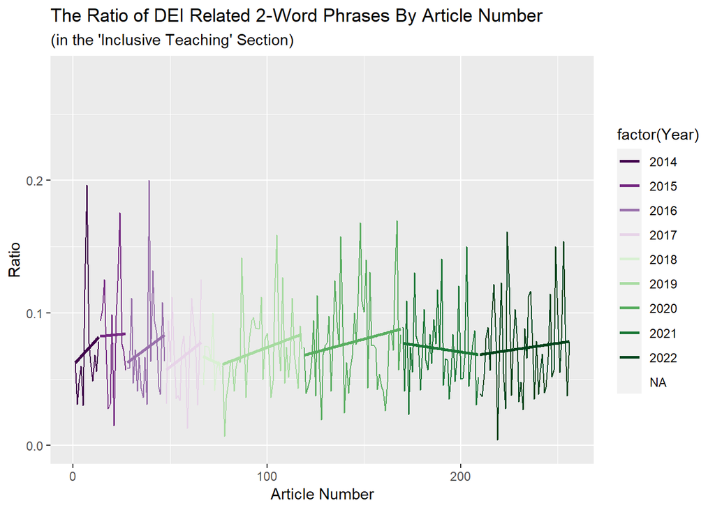

```r
df2 %>%
  ggplot(aes(`Article Number`, `DEI Ratio 2w`, colour = factor(Year))) +
  geom_line() +
  ylim(0,0.28) +
  labs(y = "Ratio", title = "The Ratio of DEI Related 2-Word Phrases By Article Number", subtitle = "(in the 'Inclusive Teaching' Section)", x = "Article Number") +
  geom_smooth(method=lm, se=FALSE) +
  scale_discrete_manual(aesthetics = "colour", values = c("#40004b", "#762a83", "#9970ab", "#e7d4e8", "#d9f0d3", "#a6dba0", "#5aae61", "#1b7837", "#00441b"))
```

### 3 word Phrases

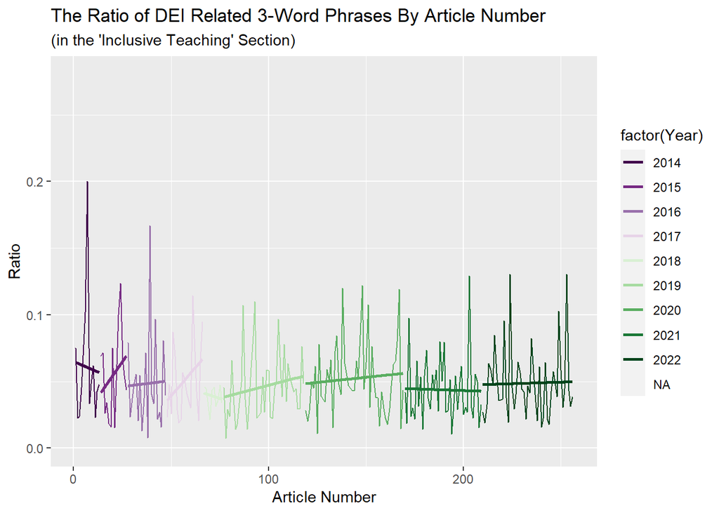

```r
df3 %>%
  ggplot(aes(`Article Number`, `DEI Ratio 3w`, colour = factor(Year))) +
  geom_line() +
  ylim(0,0.28) +
  labs(y = "Ratio", title = "The Ratio of DEI Related 3-Word Phrases By Article Number", subtitle = "(in the 'Inclusive Teaching' Section)", x = "Article Number") +
  geom_smooth(method=lm, se=FALSE) +
  scale_discrete_manual(aesthetics = "colour", values = c("#40004b", "#762a83", "#9970ab", "#e7d4e8", "#d9f0d3", "#a6dba0", "#5aae61", "#1b7837", "#00441b"))
```